# Project: Investigate a Dataset - Soccer Database Analysis

## Introduction

Soccer performance is a multifactorial process requiring high-level interaction analysis within physiological, technical, and tactical performances. At the elite level, technical staffs need to capture, process, and analyze great amounts of data, in order to measure performance in their respective teams and opponents, as well as assess potential prospects.

### Dataset Description

> **Tip**: In this project , we'll be analyzing data associated with soccer matches, players, and teams from several European countries from 2008 to 2016. In particular, we'll be interested in finding the factors that detertime a league as the top league based on ther players in regard to goal types, possession, corner, cross, fouls, cards etc…

> The dataset contains:
> - +25,000 matches
> - +10,000 players
> - 11 European Countries with their lead championship
> - Seasons 2008 to 2016
> - Players and Teams' attributes* sourced from EA Sports' FIFA video game series, including the weekly updates
> - Team line up with squad formation (X, Y coordinates)
> - Betting odds from up to 10 providers
> - Detailed match events (goal types, possession, corner, cross, fouls, cards etc…) for +10,000 matches

> **[Dataset Link](https://www.kaggle.com/datasets/hugomathien/soccer)**

### Question(s) for Analysis

> **Tip**: In this stage, we'll makes use of the application to identify key events in the game by measuring and comparing different multivariate attributes of an individual or a group of players. We'll focus on analyzing the progression of attributes during a period of time and also on revealing significant variations of different variables to the analyst.

> **Tip**: Once you start coding, use NumPy arrays, Pandas Series, and DataFrames where appropriate rather than Python lists and dictionaries. Also, **use good coding practices**, such as, define and use functions to avoid repetitive code. Use appropriate comments within the code cells, explanation in the mark-down cells, and meaningful variable names.

```python
import sqlite3
import pandas as pd
import numpy as np
import seaborn as sns
import matplotlib.pyplot as plt

%matplotlib inline

import warnings
warnings.filterwarnings("ignore")
```

```python
connection=sqlite3.connect("C:/Users/kariu/OneDrive/Desktop/Data Science/database/database.sqlite")
```

```python
# Load Data that I will investigate it
country= pd.read_sql_query("SELECT * FROM Country",connection)
league= pd.read_sql_query("SELECT * FROM League",connection)
match= pd.read_sql_query("SELECT * FROM Match",connection)
player=pd.read_sql_query("SELECT * FROM Player",connection)
player_attribute= pd.read_sql_query("SELECT * FROM Player_Attributes",connection)
team= pd.read_sql_query("SELECT * FROM Team",connection)
team_attribute= pd.read_sql_query("SELECT * FROM Team_Attributes",connection)
```

## Data Wrangling

> **Tip**: In this section of the report, you will load in the data, check for cleanliness, and then trim and clean your dataset for analysis. Make sure that you **document your data cleaning steps in mark-down cells precisely and justify your cleaning decisions.**

### General Properties

> **Tip**: You should *not* perform too many operations in each cell. Create cells freely to explore your data. One option that you can take with this project is to do a lot of explorations in an initial notebook. These don't have to be organized, but make sure you use enough comments to understand the purpose of each code cell. Then, after you're done with your analysis, create a duplicate notebook where you will trim the excess and organize your steps so that you have a flowing, cohesive report.

> **Country**

```python
country
```

|  | id | name |
| --- | --- | --- |
| 0 | 1 | Belgium |
| 1 | 1729 | England |
| 2 | 4769 | France |
| 3 | 7809 | Germany |
| 4 | 10257 | Italy |
| 5 | 13274 | Netherlands |
| 6 | 15722 | Poland |
| 7 | 17642 | Portugal |
| 8 | 19694 | Scotland |
| 9 | 21518 | Spain |
| 10 | 24558 | Switzerland |

```python
country.shape
```

```
(11, 2)
```

```python
country.info()
```

```
<class 'pandas.core.frame.DataFrame'>
RangeIndex: 11 entries, 0 to 10
Data columns (total 2 columns):
 #   Column  Non-Null Count  Dtype
---  ------  --------------  -----
 0   id      11 non-null     int64
 1   name    11 non-null     object
dtypes: int64(1), object(1)
memory usage: 304.0+ bytes
```

```python
country.describe()
```

|  | id |
| --- | --- |
| count | 11.000000 |
| mean | 12452.090909 |
| std | 8215.308472 |
| min | 1.000000 |
| 25% | 6289.000000 |
| 50% | 13274.000000 |
| 75% | 18668.000000 |
| max | 24558.000000 |

```python
country.duplicated().sum().sum()
```

```
0
```

> **League**

```python
league
```

|  | id | country_id | name |
| --- | --- | --- | --- |
| 0 | 1 | 1 | Belgium Jupiler League |
| 1 | 1729 | 1729 | England Premier League |
| 2 | 4769 | 4769 | France Ligue 1 |
| 3 | 7809 | 7809 | Germany 1. Bundesliga |
| 4 | 10257 | 10257 | Italy Serie A |
| 5 | 13274 | 13274 | Netherlands Eredivisie |
| 6 | 15722 | 15722 | Poland Ekstraklasa |
| 7 | 17642 | 17642 | Portugal Liga ZON Sagres |
| 8 | 19694 | 19694 | Scotland Premier League |
| 9 | 21518 | 21518 | Spain LIGA BBVA |
| 10 | 24558 | 24558 | Switzerland Super League |

```python
league.shape
```

```
(11, 3)
```

```python
league.info()
```

```
<class 'pandas.core.frame.DataFrame'>
RangeIndex: 11 entries, 0 to 10
Data columns (total 3 columns):
 #   Column      Non-Null Count  Dtype
---  ------      --------------  -----
 0   id          11 non-null     int64
 1   country_id  11 non-null     int64
 2   name        11 non-null     object
dtypes: int64(2), object(1)
memory usage: 392.0+ bytes
```

```python
league.describe()
```

|  | id | country_id |
| --- | --- | --- |
| count | 11.000000 | 11.000000 |
| mean | 12452.090909 | 12452.090909 |
| std | 8215.308472 | 8215.308472 |
| min | 1.000000 | 1.000000 |
| 25% | 6289.000000 | 6289.000000 |
| 50% | 13274.000000 | 13274.000000 |
| 75% | 18668.000000 | 18668.000000 |
| max | 24558.000000 | 24558.000000 |

```python
league.duplicated().sum().sum()
```

```
0
```

> **Match**

```python
match.head(2)
```

|  | id | country_id | league_id | season | stage | date | match_api_id | home_team_api_id | away_team_api_id | home_team_goal | ... | SJA | VCH | VCD | VCA | GBH | GBD | GBA | BSH | BSD | BSA |
| --- | --- | --- | --- | --- | --- | --- | --- | --- | --- | --- | --- | --- | --- | --- | --- | --- | --- | --- | --- | --- | --- |
| 0 | 1 | 1 | 1 | 2008/2009 | 1 | 2008-08-17 00:00:00 | 492473 | 9987 | 9993 | 1 | ... | 4.0 | 1.65 | 3.40 | 4.50 | 1.78 | 3.25 | 4.00 | 1.73 | 3.40 | 4.2 |
| 1 | 2 | 1 | 1 | 2008/2009 | 1 | 2008-08-16 00:00:00 | 492474 | 10000 | 9994 | 0 | ... | 3.8 | 2.00 | 3.25 | 3.25 | 1.85 | 3.25 | 3.75 | 1.91 | 3.25 | 3.6 |

2 rows × 115 columns

```python
match.shape
```

```
(25979, 115)
```

```python
match.info()
```

```
<class 'pandas.core.frame.DataFrame'>
RangeIndex: 25979 entries, 0 to 25978
Columns: 115 entries, id to BSA
dtypes: float64(96), int64(9), object(10)
memory usage: 22.8+ MB
```

```python
match.isnull().sum()
```

```
id                0
country_id        0
league_id         0
season            0
stage             0
              ...
GBD           11817
GBA           11817
BSH           11818
BSD           11818
BSA           11818
Length: 115, dtype: int64
```

```python
match.isnull().sum().sum()
```

```
407395
```

```python
match.duplicated().sum().sum()
```

```
0
```

Match Table contains 25979 Records & 115 Columns. No duplicate records Has a lot of missing values (407395) but all null values in columns I won't need in processes, So I'll drop it.

> **Player**

```python
player.head(3)
```

|  | id | player_api_id | player_name | player_fifa_api_id | birthday | height | weight |
| --- | --- | --- | --- | --- | --- | --- | --- |
| 0 | 1 | 505942 | Aaron Appindangoye | 218353 | 1992-02-29 00:00:00 | 182.88 | 187 |
| 1 | 2 | 155782 | Aaron Cresswell | 189615 | 1989-12-15 00:00:00 | 170.18 | 146 |
| 2 | 3 | 162549 | Aaron Doran | 186170 | 1991-05-13 00:00:00 | 170.18 | 163 |

```python
player.shape
```

```
(11060, 7)
```

```python
player.duplicated().sum().sum()
```

```
0
```

```python
player.isnull().sum().sum()
```

```
0
```

```python
player.describe()
```

|  | id | player_api_id | player_fifa_api_id | height | weight |
| --- | --- | --- | --- | --- | --- |
| count | 11060.000000 | 11060.000000 | 11060.000000 | 11060.000000 | 11060.000000 |
| mean | 5537.511392 | 156582.427215 | 165664.910488 | 181.867445 | 168.380289 |
| std | 3197.692647 | 160713.700624 | 58649.928360 | 6.369201 | 14.990217 |
| min | 1.000000 | 2625.000000 | 2.000000 | 157.480000 | 117.000000 |
| 25% | 2767.750000 | 35555.500000 | 151889.500000 | 177.800000 | 159.000000 |
| 50% | 5536.500000 | 96619.500000 | 184671.000000 | 182.880000 | 168.000000 |
| 75% | 8306.250000 | 212470.500000 | 203883.250000 | 185.420000 | 179.000000 |
| max | 11075.000000 | 750584.000000 | 234141.000000 | 208.280000 | 243.000000 |

```python
player.info()
```

```
<class 'pandas.core.frame.DataFrame'>
RangeIndex: 11060 entries, 0 to 11059
Data columns (total 7 columns):
 #   Column              Non-Null Count  Dtype
---  ------              --------------  -----
 0   id                  11060 non-null  int64
 1   player_api_id       11060 non-null  int64
 2   player_name         11060 non-null  object
 3   player_fifa_api_id  11060 non-null  int64
 4   birthday            11060 non-null  object
 5   height              11060 non-null  float64
 6   weight              11060 non-null  int64
dtypes: float64(1), int64(4), object(2)
memory usage: 605.0+ KB
```

> **Player Attributes**

```python
player_attribute.head(2)
```

|  | id | player_fifa_api_id | player_api_id | date | overall_rating | potential | preferred_foot | attacking_work_rate | defensive_work_rate | crossing | ... | vision | penalties | marking | standing_tackle | sliding_tackle | gk_diving | gk_handling | gk_kicking | gk_positioning | gk_reflexes |
| --- | --- | --- | --- | --- | --- | --- | --- | --- | --- | --- | --- | --- | --- | --- | --- | --- | --- | --- | --- | --- | --- |
| 0 | 1 | 218353 | 505942 | 2016-02-18 00:00:00 | 67.0 | 71.0 | right | medium | medium | 49.0 | ... | 54.0 | 48.0 | 65.0 | 69.0 | 69.0 | 6.0 | 11.0 | 10.0 | 8.0 | 8.0 |
| 1 | 2 | 218353 | 505942 | 2015-11-19 00:00:00 | 67.0 | 71.0 | right | medium | medium | 49.0 | ... | 54.0 | 48.0 | 65.0 | 69.0 | 69.0 | 6.0 | 11.0 | 10.0 | 8.0 | 8.0 |

2 rows × 42 columns

```python
player_attribute.shape
```

```
(183978, 42)
```

```python
player_attribute.info()
```

```
<class 'pandas.core.frame.DataFrame'>
RangeIndex: 183978 entries, 0 to 183977
Data columns (total 42 columns):
 #   Column               Non-Null Count   Dtype
---  ------               --------------   -----
 0   id                   183978 non-null  int64
 1   player_fifa_api_id   183978 non-null  int64
 2   player_api_id        183978 non-null  int64
 3   date                 183978 non-null  object
 4   overall_rating       183142 non-null  float64
 5   potential            183142 non-null  float64
 6   preferred_foot       183142 non-null  object
 7   attacking_work_rate  180748 non-null  object
 8   defensive_work_rate  183142 non-null  object
 9   crossing             183142 non-null  float64
```

[output cut: 34 more lines]

```python
player_attribute.duplicated().sum().sum()
```

```
0
```

```python
player_attribute.isnull().sum().sum()
```

```
47301
```

```python
player_attribute.isnull().sum()
```

```
id                        0
player_fifa_api_id        0
player_api_id             0
date                      0
overall_rating          836
potential               836
preferred_foot          836
attacking_work_rate    3230
defensive_work_rate     836
crossing                836
finishing               836
heading_accuracy        836
short_passing           836
volleys                2713
dribbling               836
curve                  2713
free_kick_accuracy      836
long_passing            836
ball_control            836
acceleration            836
sprint_speed            836
agility                2713
reactions               836
balance                2713
shot_power              836
jumping                2713
stamina                 836
strength                836
long_shots              836
aggression              836
interceptions           836
positioning             836
vision                 2713
penalties               836
marking                 836
standing_tackle         836
sliding_tackle         2713
gk_diving               836
gk_handling             836
gk_kicking              836
gk_positioning          836
gk_reflexes             836
dtype: int64
```

```python
player_attribute.describe()
```

|  | id | player_fifa_api_id | player_api_id | overall_rating | potential | crossing | finishing | heading_accuracy | short_passing | volleys | ... | vision | penalties | marking | standing_tackle | sliding_tackle | gk_diving | gk_handling | gk_kicking | gk_positioning | gk_reflexes |
| --- | --- | --- | --- | --- | --- | --- | --- | --- | --- | --- | --- | --- | --- | --- | --- | --- | --- | --- | --- | --- | --- |
| count | 183978.00000 | 183978.000000 | 183978.000000 | 183142.000000 | 183142.000000 | 183142.000000 | 183142.000000 | 183142.000000 | 183142.000000 | 181265.000000 | ... | 181265.000000 | 183142.000000 | 183142.000000 | 183142.000000 | 181265.000000 | 183142.000000 | 183142.000000 | 183142.000000 | 183142.000000 | 183142.000000 |
| mean | 91989.50000 | 165671.524291 | 135900.617324 | 68.600015 | 73.460353 | 55.086883 | 49.921078 | 57.266023 | 62.429672 | 49.468436 | ... | 57.873550 | 55.003986 | 46.772242 | 50.351257 | 48.001462 | 14.704393 | 16.063612 | 20.998362 | 16.132154 | 16.441439 |
| std | 53110.01825 | 53851.094769 | 136927.840510 | 7.041139 | 6.592271 | 17.242135 | 19.038705 | 16.488905 | 14.194068 | 18.256618 | ... | 15.144086 | 15.546519 | 21.227667 | 21.483706 | 21.598778 | 16.865467 | 15.867382 | 21.452980 | 16.099175 | 17.198155 |
| min | 1.00000 | 2.000000 | 2625.000000 | 33.000000 | 39.000000 | 1.000000 | 1.000000 | 1.000000 | 3.000000 | 1.000000 | ... | 1.000000 | 2.000000 | 1.000000 | 1.000000 | 2.000000 | 1.000000 | 1.000000 | 1.000000 | 1.000000 | 1.000000 |
| 25% | 45995.25000 | 155798.000000 | 34763.000000 | 64.000000 | 69.000000 | 45.000000 | 34.000000 | 49.000000 | 57.000000 | 35.000000 | ... | 49.000000 | 45.000000 | 25.000000 | 29.000000 | 25.000000 | 7.000000 | 8.000000 | 8.000000 | 8.000000 | 8.000000 |
| 50% | 91989.50000 | 183488.000000 | 77741.000000 | 69.000000 | 74.000000 | 59.000000 | 53.000000 | 60.000000 | 65.000000 | 52.000000 | ... | 60.000000 | 57.000000 | 50.000000 | 56.000000 | 53.000000 | 10.000000 | 11.000000 | 12.000000 | 11.000000 | 11.000000 |
| 75% | 137983.75000 | 199848.000000 | 191080.000000 | 73.000000 | 78.000000 | 68.000000 | 65.000000 | 68.000000 | 72.000000 | 64.000000 | ... | 69.000000 | 67.000000 | 66.000000 | 69.000000 | 67.000000 | 13.000000 | 15.000000 | 15.000000 | 15.000000 | 15.000000 |
| max | 183978.00000 | 234141.000000 | 750584.000000 | 94.000000 | 97.000000 | 95.000000 | 97.000000 | 98.000000 | 97.000000 | 93.000000 | ... | 97.000000 | 96.000000 | 96.000000 | 95.000000 | 95.000000 | 94.000000 | 93.000000 | 97.000000 | 96.000000 | 96.000000 |

8 rows × 38 columns

Player Attribute contains 183978 Records & 42 Columns. No duplicate records Has a lot of missing values(47301).

> **Team**

```python
team.head(2)
```

|  | id | team_api_id | team_fifa_api_id | team_long_name | team_short_name |
| --- | --- | --- | --- | --- | --- |
| 0 | 1 | 9987 | 673.0 | KRC Genk | GEN |
| 1 | 2 | 9993 | 675.0 | Beerschot AC | BAC |

```python
team.shape
```

```
(299, 5)
```

```python
team.info()
```

```
<class 'pandas.core.frame.DataFrame'>
RangeIndex: 299 entries, 0 to 298
Data columns (total 5 columns):
 #   Column            Non-Null Count  Dtype
---  ------            --------------  -----
 0   id                299 non-null    int64
 1   team_api_id       299 non-null    int64
 2   team_fifa_api_id  288 non-null    float64
 3   team_long_name    299 non-null    object
 4   team_short_name   299 non-null    object
dtypes: float64(1), int64(2), object(2)
memory usage: 11.8+ KB
```

```python
team.describe()
```

|  | id | team_api_id | team_fifa_api_id |
| --- | --- | --- | --- |
| count | 299.000000 | 299.000000 | 288.000000 |
| mean | 23735.301003 | 12340.521739 | 21534.305556 |
| std | 15167.914719 | 25940.411135 | 42456.439408 |
| min | 1.000000 | 1601.000000 | 1.000000 |
| 25% | 9552.500000 | 8349.000000 | 178.750000 |
| 50% | 22805.000000 | 8655.000000 | 673.500000 |
| 75% | 36250.500000 | 9886.500000 | 1910.750000 |
| max | 51606.000000 | 274581.000000 | 112513.000000 |

```python
team.isnull().sum().sum()
```

```
11
```

```python
team.duplicated().sum().sum()
```

```
0
```

Team contains 299 recods & 5 columns. Has no duplicate values but has null values in the `team_fifa_api_id` column so we'll drop them

> **Team Attributes**

```python
team_attribute.head()
```

|  | id | team_fifa_api_id | team_api_id | date | buildUpPlaySpeed | buildUpPlaySpeedClass | buildUpPlayDribbling | buildUpPlayDribblingClass | buildUpPlayPassing | buildUpPlayPassingClass | ... | chanceCreationShooting | chanceCreationShootingClass | chanceCreationPositioningClass | defencePressure | defencePressureClass | defenceAggression | defenceAggressionClass | defenceTeamWidth | defenceTeamWidthClass | defenceDefenderLineClass |
| --- | --- | --- | --- | --- | --- | --- | --- | --- | --- | --- | --- | --- | --- | --- | --- | --- | --- | --- | --- | --- | --- |
| 0 | 1 | 434 | 9930 | 2010-02-22 00:00:00 | 60 | Balanced | NaN | Little | 50 | Mixed | ... | 55 | Normal | Organised | 50 | Medium | 55 | Press | 45 | Normal | Cover |
| 1 | 2 | 434 | 9930 | 2014-09-19 00:00:00 | 52 | Balanced | 48.0 | Normal | 56 | Mixed | ... | 64 | Normal | Organised | 47 | Medium | 44 | Press | 54 | Normal | Cover |
| 2 | 3 | 434 | 9930 | 2015-09-10 00:00:00 | 47 | Balanced | 41.0 | Normal | 54 | Mixed | ... | 64 | Normal | Organised | 47 | Medium | 44 | Press | 54 | Normal | Cover |
| 3 | 4 | 77 | 8485 | 2010-02-22 00:00:00 | 70 | Fast | NaN | Little | 70 | Long | ... | 70 | Lots | Organised | 60 | Medium | 70 | Double | 70 | Wide | Cover |
| 4 | 5 | 77 | 8485 | 2011-02-22 00:00:00 | 47 | Balanced | NaN | Little | 52 | Mixed | ... | 52 | Normal | Organised | 47 | Medium | 47 | Press | 52 | Normal | Cover |

5 rows × 25 columns

```python
team_attribute.shape
```

```
(1458, 25)
```

```python
team_attribute.info()
```

```
<class 'pandas.core.frame.DataFrame'>
RangeIndex: 1458 entries, 0 to 1457
Data columns (total 25 columns):
 #   Column                          Non-Null Count  Dtype
---  ------                          --------------  -----
 0   id                              1458 non-null   int64
 1   team_fifa_api_id                1458 non-null   int64
 2   team_api_id                     1458 non-null   int64
 3   date                            1458 non-null   object
 4   buildUpPlaySpeed                1458 non-null   int64
 5   buildUpPlaySpeedClass           1458 non-null   object
 6   buildUpPlayDribbling            489 non-null    float64
 7   buildUpPlayDribblingClass       1458 non-null   object
 8   buildUpPlayPassing              1458 non-null   int64
 9   buildUpPlayPassingClass         1458 non-null   object
```

[output cut: 17 more lines]

```python
team_attribute.describe()
```

|  | id | team_fifa_api_id | team_api_id | buildUpPlaySpeed | buildUpPlayDribbling | buildUpPlayPassing | chanceCreationPassing | chanceCreationCrossing | chanceCreationShooting | defencePressure | defenceAggression | defenceTeamWidth |
| --- | --- | --- | --- | --- | --- | --- | --- | --- | --- | --- | --- | --- |
| count | 1458.000000 | 1458.000000 | 1458.000000 | 1458.000000 | 489.000000 | 1458.000000 | 1458.000000 | 1458.000000 | 1458.000000 | 1458.000000 | 1458.000000 | 1458.000000 |
| mean | 729.500000 | 17706.982167 | 9995.727023 | 52.462277 | 48.607362 | 48.490398 | 52.165295 | 53.731824 | 53.969136 | 46.017147 | 49.251029 | 52.185871 |
| std | 421.032659 | 39179.857739 | 13264.869900 | 11.545869 | 9.678290 | 10.896101 | 10.360793 | 11.086796 | 10.327566 | 10.227225 | 9.738028 | 9.574712 |
| min | 1.000000 | 1.000000 | 1601.000000 | 20.000000 | 24.000000 | 20.000000 | 21.000000 | 20.000000 | 22.000000 | 23.000000 | 24.000000 | 29.000000 |
| 25% | 365.250000 | 110.000000 | 8457.750000 | 45.000000 | 42.000000 | 40.000000 | 46.000000 | 47.000000 | 48.000000 | 39.000000 | 44.000000 | 47.000000 |
| 50% | 729.500000 | 485.000000 | 8674.000000 | 52.000000 | 49.000000 | 50.000000 | 52.000000 | 53.000000 | 53.000000 | 45.000000 | 48.000000 | 52.000000 |
| 75% | 1093.750000 | 1900.000000 | 9904.000000 | 62.000000 | 55.000000 | 55.000000 | 59.000000 | 62.000000 | 61.000000 | 51.000000 | 55.000000 | 58.000000 |
| max | 1458.000000 | 112513.000000 | 274581.000000 | 80.000000 | 77.000000 | 80.000000 | 80.000000 | 80.000000 | 80.000000 | 72.000000 | 72.000000 | 73.000000 |

```python
team_attribute.duplicated().sum().sum()
```

```
0
```

```python
team_attribute.isnull().sum()
```

```
id                                  0
team_fifa_api_id                    0
team_api_id                         0
date                                0
buildUpPlaySpeed                    0
buildUpPlaySpeedClass               0
buildUpPlayDribbling              969
buildUpPlayDribblingClass           0
buildUpPlayPassing                  0
buildUpPlayPassingClass             0
buildUpPlayPositioningClass         0
chanceCreationPassing               0
chanceCreationPassingClass          0
chanceCreationCrossing              0
chanceCreationCrossingClass         0
chanceCreationShooting              0
chanceCreationShootingClass         0
chanceCreationPositioningClass      0
defencePressure                     0
defencePressureClass                0
defenceAggression                   0
defenceAggressionClass              0
defenceTeamWidth                    0
defenceTeamWidthClass               0
defenceDefenderLineClass            0
dtype: int64
```

Team Attribute containes 1458 records & 25 columns. Has null values in the `buildUpPlayDribbling` column so we'll drop it

### Summary:

| Table | Records | Columns |
| --- | --- | --- |
| Country | 11 | 2 |
| League | 11 | 3 |
| Match | 25979 | 115 |
| Player | 11060 | 7 |
| Player_Attributes | 183978 | 42 |
| Team | 299 | 5 |
| Team_Attributes | 1458 | 25 |

## **Data Cleaning**

> **1. Let's start with the Matches Table**

> We will begin by selecting the columns we will need for the analysis

```python
match=match.loc[:,:'away_team_goal']
```

```python
match.info()
```

```
<class 'pandas.core.frame.DataFrame'>
RangeIndex: 25979 entries, 0 to 25978
Data columns (total 11 columns):
 #   Column            Non-Null Count  Dtype
---  ------            --------------  -----
 0   id                25979 non-null  int64
 1   country_id        25979 non-null  int64
 2   league_id         25979 non-null  int64
 3   season            25979 non-null  object
 4   stage             25979 non-null  int64
 5   date              25979 non-null  object
 6   match_api_id      25979 non-null  int64
 7   home_team_api_id  25979 non-null  int64
 8   away_team_api_id  25979 non-null  int64
 9   home_team_goal    25979 non-null  int64
 10  away_team_goal    25979 non-null  int64
dtypes: int64(9), object(2)
memory usage: 2.2+ MB
```

```
  Let's convert Date to DateTime type to gain availability to dedicate a year of each date
```

```python
match['date'] = pd.to_datetime(match['date'])
```

> Let's add a new column to store the match table years

```python
match['season_year']=match['date'].dt.year
```

Maximum and Minimum year in season year column

```python
str(match['season_year'].min()) + " : " + str(match['season_year'].max())
```

```
'2008 : 2016'
```

```python
# rename column: name to country_name
country.rename(columns={'name' : 'country_name', }, inplace=True)
```

```python
# join match with country table by inner join type .
match=match.merge(country, how='inner', left_on= "country_id", right_on = "id")
```

```python
# drop column id_y
match.drop(columns=['id_y'], inplace=True)
# rename column: id_x to id
match.rename(columns={'id_x' : 'id'}, inplace=True)
match.head()
```

[output not shown]

> Let's join match with team table by **inner join** type for `home team`

```python
match=match.merge(team, how='inner', left_on='home_team_api_id', right_on='team_api_id')
# rename column: team_long_name to home_team_name
match.rename(columns={'team_long_name': 'home_team_name','country_name_x'  : 'country_name' , 'id_x' : 'id'}, inplace=True)
```

```python
# drop column home_team_api_id and team_api_id
match.drop(columns=['home_team_api_id', 'team_api_id', 'id_y'], axis=1, inplace=True)
match.head()
```

|  | id | country_id | league_id | season | stage | date | match_api_id | away_team_api_id | home_team_goal | away_team_goal | season_year | country_name | id | country_name_y | team_fifa_api_id | home_team_name | team_short_name |
| --- | --- | --- | --- | --- | --- | --- | --- | --- | --- | --- | --- | --- | --- | --- | --- | --- | --- |
| 0 | 1 | 1 | 1 | 2008/2009 | 1 | 2008-08-17 | 492473 | 9993 | 1 | 1 | 2008 | Belgium | 1 | Belgium | 673.0 | KRC Genk | GEN |
| 1 | 29 | 1 | 1 | 2008/2009 | 12 | 2008-11-15 | 492583 | 9999 | 1 | 1 | 2008 | Belgium | 1 | Belgium | 673.0 | KRC Genk | GEN |
| 2 | 47 | 1 | 1 | 2008/2009 | 14 | 2008-11-29 | 492651 | 9984 | 3 | 2 | 2008 | Belgium | 1 | Belgium | 673.0 | KRC Genk | GEN |
| 3 | 65 | 1 | 1 | 2008/2009 | 16 | 2008-12-13 | 492713 | 9986 | 1 | 0 | 2008 | Belgium | 1 | Belgium | 673.0 | KRC Genk | GEN |
| 4 | 94 | 1 | 1 | 2008/2009 | 19 | 2009-01-24 | 492805 | 9998 | 2 | 0 | 2009 | Belgium | 1 | Belgium | 673.0 | KRC Genk | GEN |

> Let's join match with team table by **left join** type for `away team`

```python
match=match.merge(team, how='left', left_on='away_team_api_id', right_on='team_api_id')
# rename column: team_long_name to away_team_name , id_x to id
match.rename(columns={'team_long_name': 'away_team_name', 'id_x' : 'id'}, inplace=True)
```

```python
# drop unnecessary columns
match.drop(columns=['team_api_id', 'away_team_api_id','team_fifa_api_id_x', 'team_fifa_api_id_y','team_fifa_api_id_y','team_short_name_y','id_y'], axis=1, inplace=True)
match.info()
```

```
<class 'pandas.core.frame.DataFrame'>
Int64Index: 25979 entries, 0 to 25978
Data columns (total 16 columns):
 #   Column             Non-Null Count  Dtype
---  ------             --------------  -----
 0   id                 25979 non-null  int64
 1   country_id         25979 non-null  int64
 2   league_id          25979 non-null  int64
 3   season             25979 non-null  object
 4   stage              25979 non-null  int64
 5   date               25979 non-null  datetime64[ns]
 6   match_api_id       25979 non-null  int64
 7   home_team_goal     25979 non-null  int64
 8   away_team_goal     25979 non-null  int64
 9   season_year        25979 non-null  int64
 10  country_name       25979 non-null  object
 11  id                 25979 non-null  int64
 12  country_name_y     25979 non-null  object
 13  home_team_name     25979 non-null  object
 14  team_short_name_x  25979 non-null  object
 15  away_team_name     25979 non-null  object
dtypes: datetime64[ns](1), int64(9), object(6)
memory usage: 3.4+ MB
```

> Let's join match with league table by **inner join** type for `away team`

```python
# rename the two columns 'name' and 'id'
league.rename(columns={'name': 'league_name', 'id': 'league_id'}, inplace=True)
# join df_match with league table by inner join type for away team
match=match.merge(league, how='inner', on='league_id')
```

```python
# drop now country_id and league_id
match.drop(columns=["league_id","country_id_y" , "country_id_x"], inplace=True)
match.describe()
```

|  | id | stage | match_api_id | home_team_goal | away_team_goal | season_year | id |
| --- | --- | --- | --- | --- | --- | --- | --- |
| count | 25979.000000 | 25979.000000 | 2.597900e+04 | 25979.000000 | 25979.000000 | 25979.000000 | 25979.000000 |
| mean | 12990.000000 | 18.242773 | 1.195429e+06 | 1.544594 | 1.160938 | 2011.998653 | 11738.630317 |
| std | 7499.635658 | 10.407354 | 4.946279e+05 | 1.297158 | 1.142110 | 2.354741 | 7553.936759 |
| min | 1.000000 | 1.000000 | 4.831290e+05 | 0.000000 | 0.000000 | 2008.000000 | 1.000000 |
| 25% | 6495.500000 | 9.000000 | 7.684365e+05 | 1.000000 | 0.000000 | 2010.000000 | 4769.000000 |
| 50% | 12990.000000 | 18.000000 | 1.147511e+06 | 1.000000 | 1.000000 | 2012.000000 | 10257.000000 |
| 75% | 19484.500000 | 27.000000 | 1.709852e+06 | 2.000000 | 2.000000 | 2014.000000 | 17642.000000 |
| max | 25979.000000 | 38.000000 | 2.216672e+06 | 10.000000 | 9.000000 | 2016.000000 | 24558.000000 |

Let's see if there are any missed values before we start the analysis

```python
match.isna().sum().sum()
```

```
0
```

> **2. Let's clean the Players Table**

> Let's join player with player_attribute table by **inner join** type to easy found player name with attributes

```python
player=player.merge(player_attribute, on=['player_api_id','player_fifa_api_id'], how = "inner")
# rename column: id_x to id
player.rename(columns={'id_x' : 'id'}, inplace=True)
```

```python
# drop column id_y,player_api_id, player_fifa_api_id
player.drop(columns=["id_y","player_api_id" , "player_fifa_api_id"], inplace=True)
player.info()
```

```
<class 'pandas.core.frame.DataFrame'>
Int64Index: 183766 entries, 0 to 183765
Data columns (total 44 columns):
 #   Column               Non-Null Count   Dtype
---  ------               --------------   -----
 0   id                   183766 non-null  int64
 1   player_name          183766 non-null  object
 2   birthday             183766 non-null  object
 3   height               183766 non-null  float64
 4   weight               183766 non-null  int64
 5   date                 183766 non-null  object
 6   overall_rating       183016 non-null  float64
 7   potential            183016 non-null  float64
 8   preferred_foot       183016 non-null  object
 9   attacking_work_rate  180622 non-null  object
```

[output cut: 36 more lines]

```python
## Drop duplicated records
player.drop_duplicates(inplace = True)
```

```python
player.duplicated().sum().sum()
```

```
0
```

```python
## Drop records have missed value
player.dropna(inplace=True)
```

```python
player.isna().sum().sum()
```

```
0
```

> Let's drop the `buildUpPlayDribbling` column which has most missed values in team table

```python
team_attribute.drop(columns=['buildUpPlayDribbling'], axis=1, inplace=True)
```

```python
team_attribute.isnull().sum().sum()
```

```
0
```

> Let's join team with team_attribute table by inner join type to easy merge name of name beside Their attributes

```python
team=team.merge(team_attribute , on = ['team_api_id','team_fifa_api_id'], how = 'inner')
# drop column id_y,team_api_id, team_fifa_api_id, team_short_name
```

```python
team.drop(columns=["id_y","team_api_id" , "team_fifa_api_id","team_short_name"], inplace=True)
# rename column: id_x to id
team.rename(columns={'id_x': 'id'}, inplace=True)
```

```python
player.info()
```

```
<class 'pandas.core.frame.DataFrame'>
Int64Index: 180228 entries, 0 to 183765
Data columns (total 44 columns):
 #   Column               Non-Null Count   Dtype
---  ------               --------------   -----
 0   id                   180228 non-null  int64
 1   player_name          180228 non-null  object
 2   birthday             180228 non-null  object
 3   height               180228 non-null  float64
 4   weight               180228 non-null  int64
 5   date                 180228 non-null  object
 6   overall_rating       180228 non-null  float64
 7   potential            180228 non-null  float64
 8   preferred_foot       180228 non-null  object
 9   attacking_work_rate  180228 non-null  object
```

[output cut: 36 more lines]

> Let's add new year column to team table

```python
#convert date to datatime type to get year easily
team['date'] = pd.to_datetime(team['date'])
```

```python
team['year']=team['date'].dt.year
```

```python
team.info()
```

```
<class 'pandas.core.frame.DataFrame'>
Int64Index: 1458 entries, 0 to 1457
Data columns (total 24 columns):
 #   Column                          Non-Null Count  Dtype
---  ------                          --------------  -----
 0   id                              1458 non-null   int64
 1   team_long_name                  1458 non-null   object
 2   date                            1458 non-null   datetime64[ns]
 3   buildUpPlaySpeed                1458 non-null   int64
 4   buildUpPlaySpeedClass           1458 non-null   object
 5   buildUpPlayDribblingClass       1458 non-null   object
 6   buildUpPlayPassing              1458 non-null   int64
 7   buildUpPlayPassingClass         1458 non-null   object
 8   buildUpPlayPositioningClass     1458 non-null   object
 9   chanceCreationPassing           1458 non-null   int64
```

[output cut: 16 more lines]

```python
## Drop records have missed value
team.dropna(inplace=True)
## Drop duplicated records
team.drop_duplicates(inplace = True)
```

```python
team.isnull().sum().sum()
```

```
0
```

```python
team.duplicated().sum().sum()
```

```
0
```

## Exploratory Data Analysis

### How can we measure the competitiveness of a league?

> A first approach is the total number of goals scored in the season, if we have high number that can mean a high number of attacks in the games.

```python
leagues_by_season = pd.read_sql("""SELECT Country.name AS country_name,
                                        League.name AS league_name,
                                        season,
                                        count(distinct stage) AS number_of_stages,
                                        count(distinct HT.team_long_name) AS number_of_teams,
                                        avg(home_team_goal) AS avg_home_team_scors,
                                        avg(away_team_goal) AS avg_away_team_goals,
                                        avg(home_team_goal-away_team_goal) AS avg_goal_dif,
                                        avg(home_team_goal+away_team_goal) AS avg_goals,
                                        sum(home_team_goal+away_team_goal) AS total_goals
                                FROM Match
                                JOIN Country on Country.id = Match.country_id
                                JOIN League on League.id = Match.league_id
                                LEFT JOIN Team AS HT on HT.team_api_id = Match.home_team_api_id
                                LEFT JOIN Team AS AT on AT.team_api_id = Match.away_team_api_id
                                WHERE country_name in ('Belgium', 'England', 'France', 'Germany', 'Italy', 'Netherlands', 'Poland', 'Portugal', 'Scotland', 'Spain', 'Switzerland')
                                GROUP BY Country.name, League.name, season
                                HAVING count(distinct stage) > 10
                                ORDER BY Country.name, League.name, season
                                ;""", connection)
```

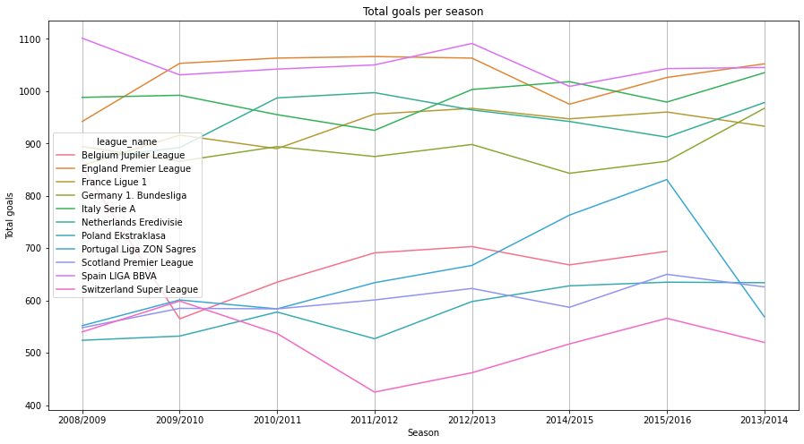

```python
plt.figure(figsize=(15,8))
sns.lineplot(data=leagues_by_season, x="season", y="total_goals",hue="league_name")
plt.xlabel("Season")
plt.ylabel("Total goals")
plt.title("Total goals per season")
plt.grid(axis = 'x')
plt.show()
```

Although all the goals in one game can be score by only one team so this measure isn´t really telling the degree of competitivity.

A more precise view could be the averege goal difference per match, this capture a more realistic difference between the teams, if it is low the game was even.

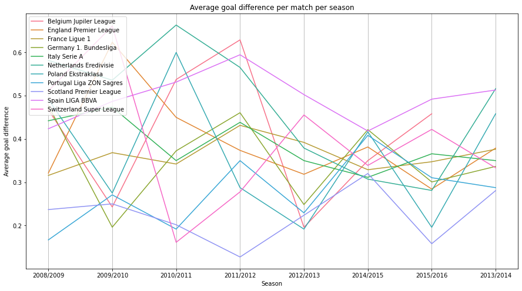

```python
plt.figure(figsize=(15,8))
sns.lineplot(data=leagues_by_season, x="season", y="avg_goal_dif",hue="league_name")
plt.xlabel("Season")
plt.ylabel("Average goal difference")
plt.title("Average goal difference per match per season")
plt.grid(axis='x')
plt.legend(loc='upper left')
plt.show()
```

> Let's focus on the 2015/2016 year

> **How many matches are there in the 2016 season?**

Create a function that returns name of winner team from every match

```python
def win(match):
    """
    Input: DataFrame contains 4 columns:
                                        `home_team_goal`,
                                        `away_team_goal`,
                                        `home_team_name`,
                                        `away_team_name`
    OutPut: New Column for winner teams
    """
    home_score=match[0] #home_team_goal
    away_score=match[1] #away_team_goal
    home_team_name=match[2] #home_team_name
    away_team_name=match[3] #away_team_name

    if home_score > away_score:
        return home_team_name
    elif home_score < away_score:
        return away_team_name
    else:
        return 'DRAW'
```

> Add new column to store winners team within the Win Function

```python
match['winner']=match[['home_team_goal', 'away_team_goal', 'home_team_name', 'away_team_name']].apply(win, axis=1)
```

> Let's filter matches that were only played in the 2015/2016 season

```python
match_2016=match[match['season'] == '2015/2016']
match_2016
```

|  | id | season | stage | date | match_api_id | home_team_goal | away_team_goal | season_year | country_name | id | country_name_y | home_team_name | team_short_name_x | away_team_name | league_name | winner |
| --- | --- | --- | --- | --- | --- | --- | --- | --- | --- | --- | --- | --- | --- | --- | --- | --- |
| 91 | 1491 | 2015/2016 | 1 | 2015-07-25 | 1979834 | 3 | 1 | 2015 | Belgium | 1 | Belgium | KRC Genk | GEN | Oud-Heverlee Leuven | Belgium Jupiler League | KRC Genk |
| 92 | 1499 | 2015/2016 | 10 | 2015-10-04 | 1979898 | 3 | 1 | 2015 | Belgium | 1 | Belgium | KRC Genk | GEN | Standard de Liège | Belgium Jupiler League | KRC Genk |
| 93 | 1515 | 2015/2016 | 12 | 2015-10-23 | 1979914 | 0 | 4 | 2015 | Belgium | 1 | Belgium | KRC Genk | GEN | Royal Excel Mouscron | Belgium Jupiler League | Royal Excel Mouscron |
| 94 | 1530 | 2015/2016 | 14 | 2015-10-30 | 1979929 | 0 | 2 | 2015 | Belgium | 1 | Belgium | KRC Genk | GEN | Sporting Lokeren | Belgium Jupiler League | Sporting Lokeren |
| 95 | 1554 | 2015/2016 | 17 | 2015-11-28 | 1979953 | 0 | 1 | 2015 | Belgium | 1 | Belgium | KRC Genk | GEN | KAA Gent | Belgium Jupiler League | KAA Gent |
| ... | ... | ... | ... | ... | ... | ... | ... | ... | ... | ... | ... | ... | ... | ... | ... | ... |
| 25974 | 25936 | 2015/2016 | 34 | 2016-05-16 | 1992217 | 1 | 3 | 2016 | Switzerland | 24558 | Switzerland | Lugano | LUG | BSC Young Boys | Switzerland Super League | BSC Young Boys |
| 25975 | 25946 | 2015/2016 | 36 | 2016-05-25 | 1992226 | 3 | 0 | 2016 | Switzerland | 24558 | Switzerland | Lugano | LUG | FC St. Gallen | Switzerland Super League | Lugano |
| 25976 | 25960 | 2015/2016 | 6 | 2015-08-22 | 1992076 | 1 | 3 | 2015 | Switzerland | 24558 | Switzerland | Lugano | LUG | FC Basel | Switzerland Super League | FC Basel |
| 25977 | 25965 | 2015/2016 | 7 | 2015-08-29 | 1992081 | 0 | 1 | 2015 | Switzerland | 24558 | Switzerland | Lugano | LUG | FC Luzern | Switzerland Super League | FC Luzern |
| 25978 | 25978 | 2015/2016 | 9 | 2015-09-22 | 1992094 | 0 | 0 | 2015 | Switzerland | 24558 | Switzerland | Lugano | LUG | FC Zürich | Switzerland Super League | DRAW |

3326 rows × 16 columns

> Let's count every match played in each league in the 2015/2016 season

```python
match_played=match_2016.groupby('league_name')['home_team_name'].count().sort_values()
match_played
```

```
league_name
Switzerland Super League    180
Scotland Premier League     228
Belgium Jupiler League      240
Poland Ekstraklasa          240
Germany 1. Bundesliga       306
Netherlands Eredivisie      306
Portugal Liga ZON Sagres    306
England Premier League      380
France Ligue 1              380
Italy Serie A               380
Spain LIGA BBVA             380
Name: home_team_name, dtype: int64
```

> Let's vusialize these results

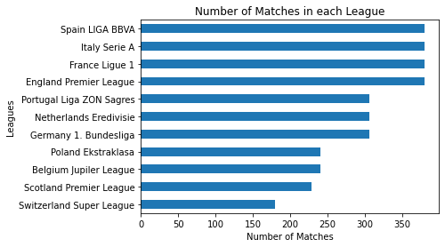

```python
match_played.plot(kind='barh', title='Number of Matches in each League');
plt.xlabel('Number of Matches');
plt.ylabel('Leagues');
```

> **Which team had lost the fewest matches in the 2016 season?** This question gives us an impression that these teams has a great defense and Goalkeeper

```python
# Add New Column for loser teams within lose function
def lose(match):
    """"
    Input: DataFrame contain 4 Columns:
                                    `home_team_goal`,
                                    `away_team_goal`,
                                    `home_team_name`,
                                    `away_team_name`
    OutPut: New Column f9r loser teams
    """
    home_score=match[0] #home_team_goal
    away_score=match[1] #away_team_goal
    home_team_name=match[2] #home_team_name
    away_team_name=match[3] #away_team_name

    if home_score < away_score:
        return home_team_name
    elif home_score > away_score:
        return away_team_name
    else:
        return 'DRAW'
```

```python
match['loser']=match[['home_team_goal', 'away_team_goal', 'home_team_name', 'away_team_name']].apply(lose, axis=1)
```

> Let's viualize the results

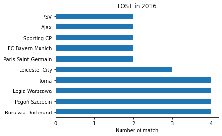

```python
match_2016=match[match['season'] == '2015/2016']

match_2016.loser.value_counts().tail(10).plot(kind='barh', title='LOST in 2016',xticks = [0,1,2,3,4])
plt.xlabel('Number of match');
```

> **Now that we've seen which teams had lost the fewest matches, let's look at the teams that had the most wins of matches in the 2016 season?**

```python
wins_16=match_2016.winner.value_counts().head(10).iloc[1:]
wins_16
```

```
Paris Saint-Germain    30
Juventus               29
SL Benfica             29
FC Barcelona           29
Real Madrid CF         28
Atlético Madrid        28
FC Bayern Munich       28
Sporting CP            27
Celtic                 26
Name: winner, dtype: int64
```

> Let's visualize this

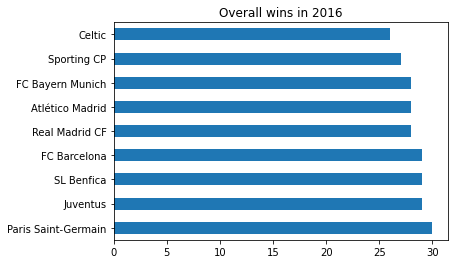

```python
wins_16.plot(kind='barh', title='Overall wins in 2016');
```

> **Let's looks at the leagues that had the most matches end as a draw in the 2016 season?**

```python
match_2016[['winner',"league_name"]].value_counts().loc["DRAW"]
```

```
league_name
France Ligue 1              108
England Premier League      107
Italy Serie A                95
Spain LIGA BBVA              92
Portugal Liga ZON Sagres     76
Poland Ekstraklasa           74
Netherlands Eredivisie       74
Germany 1. Bundesliga        71
Belgium Jupiler League       59
Scotland Premier League      52
Switzerland Super League     47
dtype: int64
```

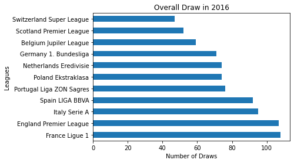

```python
match_2016[['winner',"league_name"]].value_counts().loc["DRAW"].plot(kind='barh')
plt.xlabel('Number of Draws');
plt.ylabel('Leagues');
plt.title('Overall Draw in 2016');
```

> **Let's see how many goals there are in each League in the 2016 season**

```python
goals_2016=match_2016.groupby('league_name')['home_team_goal'].sum().sort_values(ascending=False) + match_2016.groupby('league_name')['away_team_goal'].sum().sort_values(ascending=False)
goals_2016.sort_values(ascending=False, inplace =True)
goals_2016
```

```
league_name
Spain LIGA BBVA             1043
England Premier League      1026
Italy Serie A                979
France Ligue 1               960
Netherlands Eredivisie       912
Germany 1. Bundesliga        866
Portugal Liga ZON Sagres     831
Belgium Jupiler League       694
Scotland Premier League      650
Poland Ekstraklasa           635
Switzerland Super League     566
dtype: int64
```

```python
wins16=match_2016.groupby(["league_name"]).apply(lambda x: (x["winner"]!='DRAW').sum()).reset_index(name='winner').sort_values('winner')
wins16
```

|  | league_name | winner |
| --- | --- | --- |
| 10 | Switzerland Super League | 133 |
| 6 | Poland Ekstraklasa | 166 |
| 8 | Scotland Premier League | 176 |
| 0 | Belgium Jupiler League | 181 |
| 7 | Portugal Liga ZON Sagres | 230 |
| 5 | Netherlands Eredivisie | 232 |
| 3 | Germany 1. Bundesliga | 235 |
| 2 | France Ligue 1 | 272 |
| 1 | England Premier League | 273 |
| 4 | Italy Serie A | 285 |
| 9 | Spain LIGA BBVA | 288 |

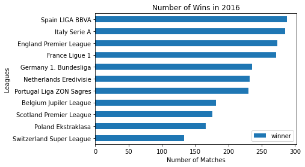

```python
wins16.plot(x= 'league_name' ,kind='barh')
plt.xlabel('Number of Matches');
plt.ylabel('Leagues');
plt.title('Number of Wins in 2016');
```

> **Let's look at the team improvements over the time period**

To do this, we'll choose 2 different years to cover a long period. **2010-2016** to compare the details of the teams. In order words, using these years we analyze what teams improved the most.

Now let's select the number of wins in 2010 and 2016 and take the difference in order to return the process to calculate loses match for every team in 2010 and 2016

```python
# Select wins games in 2010
wins_2010=match[(match['season_year'] == 2010) & (match['winner'] != 'DRAW')]
# Select lose games in 2010
loses_2010=match[(match['season_year'] == 2010) & (match['loser'] != 'DRAW')]
```

```python
# count wins games in 2010
countWins_2010=wins_2010['winner'].count()
# count lose games in 2010
countLoses_2010=loses_2010['loser'].count()
```

```python
# Sustract between winner and loser in 2010
Balance_2010=wins_2010['winner'].value_counts()/countWins_2010 - loses_2010['loser'].value_counts()/countLoses_2010
```

> Do the same for `2016`

```python
# Select wins games in 2016
wins_2016=match[(match['season_year'] == 2016) & (match['winner'] != 'DRAW')]
# Select lose games in 2016
loses_2016=match[(match['season_year'] == 2016) & (match['loser'] != 'DRAW')]
```

```python
# count wins games in 2016
countWins_2016=wins_2016['winner'].count()
# count lose games in 2016
countLoses_2016=loses_2016['loser'].count()
```

```python
# Sustract between winner and loser in 2010
Balance_2016=wins_2016['winner'].value_counts()/countWins_2016 - loses_2016['loser'].value_counts()/countLoses_2016
```

##### Take the average of total number of goals scored for each team in 2010 and 2016 and subtract them

```python
# Select wins match in 2010
match_2010=match[match['season_year'] == 2010]
# Select wins match in 2016
match_2016=match[match['season_year'] == 2016]
```

> Average home and away goals for `2010` and `2016`

```python
#select average of away team goal in 2010
match_2010_away=match_2010.groupby(['away_team_name'])['away_team_goal'].mean()
#select average of home team goal in 2010
match_2010_home=match_2010.groupby(['home_team_name'])['home_team_goal'].mean()
```

```python
#select average of away team goal in 2016
match_2016_away=match_2016.groupby(['away_team_name'])['away_team_goal'].mean()
#select average of home team goal in 2010
match_2016_home=match_2016.groupby(['home_team_name'])['home_team_goal'].mean()
```

> Average of all team goals of `2010` and `2016`

```python
#select average of all team goal in 2010
match_total_2010=(match_2010_away + match_2010_home) / 2
#select average of all team goal in 2016
match_total_2016=(match_2016_away + match_2016_home) / 2
```

> Select the rate of change

Subtract the average of all team goals in `2010` and `2016` then add result to subtract wins and loses

```python
diff_match_2016_2010=((match_total_2016 - match_total_2010) + ( Balance_2016 - Balance_2010)) /2
```

```python
diff_match_2016_2010
```

```
away_team_name
1. FC Kaiserslautern            NaN
1. FC Köln                -0.018257
1. FC Nürnberg                  NaN
1. FSV Mainz 05            0.013671
AC Arles-Avignon                NaN
                             ...
Wisła Kraków               0.264342
Wolverhampton Wanderers         NaN
Xerez Club Deportivo            NaN
Zagłębie Lubin             0.241290
Śląsk Wrocław             -0.209841
Length: 258, dtype: float64
```

> Now, we want to visualize the teams that improved and those that didn't improve.

First, we need to create a function to store color of improved team and not improved

```python
# purple color for positive values and pink color for negative values
color = []
def coloring(df):
        '''
        input: DataFrame about rate of change match_2016_2010
        Output: New column store color of all teams
        '''
        if df < 0:
            return 'pink' #red color for negative values
        else:
            return 'purple'  #green color for positive values
#call function coloring and store the result in color list
color= diff_match_2016_2010.sort_values().apply(coloring)
```

```python
diff_match_2016_2010.dropna(inplace=True)
print('Improved teams :' + str(diff_match_2016_2010[diff_match_2016_2010.sort_values() > 0].count()))
```

```
Improved teams :73
```

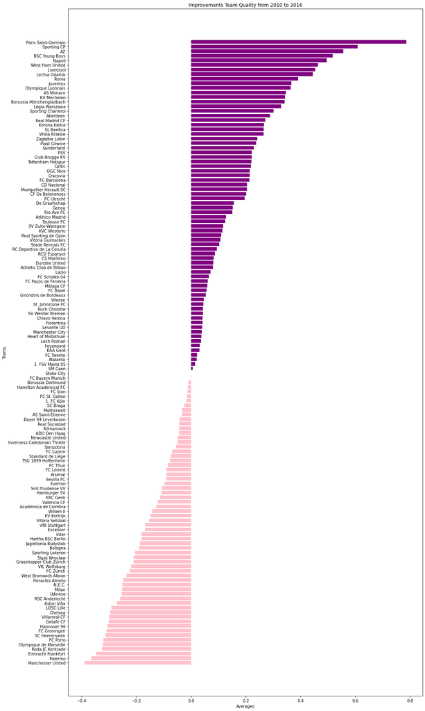

```python
# sort the values
sorted_index = diff_match_2016_2010.sort_values().index

fig, ax = plt.subplots(figsize=(15, 25))
plt.barh(range(0,len(sorted_index)), diff_match_2016_2010.sort_values(),color = color)
ax.set_yticks(range(0,len(sorted_index)))
ax.set_yticklabels(sorted_index)
ax.set_ylabel('Teams')
ax.set_title('Improvements Team Quality from 2010 to 2016')
plt.xlabel("Averages")
plt.tight_layout();
```

## Player analysis

> **Players that have overall rating more than 90**

```python
# Select Maximum Rate
player['overall_rating'].max()
```

```
94.0
```

```python
# average of players' overall rating
average_rate=player['overall_rating'].mean()
average_rate
```

```
68.63280955234481
```

```python
above_rating=player[player['overall_rating'] > average_rate]
above_rating.player_name.nunique()
```

```
6467
```

```python
pd.DataFrame(above_rating.describe())
```

|  | id | height | weight | overall_rating | potential | crossing | finishing | heading_accuracy | short_passing | volleys | ... | vision | penalties | marking | standing_tackle | sliding_tackle | gk_diving | gk_handling | gk_kicking | gk_positioning | gk_reflexes |
| --- | --- | --- | --- | --- | --- | --- | --- | --- | --- | --- | --- | --- | --- | --- | --- | --- | --- | --- | --- | --- | --- |
| count | 92330.000000 | 92330.000000 | 92330.000000 | 92330.000000 | 92330.000000 | 92330.000000 | 92330.000000 | 92330.000000 | 92330.000000 | 92330.000000 | ... | 92330.000000 | 92330.000000 | 92330.000000 | 92330.000000 | 92330.000000 | 92330.000000 | 92330.000000 | 92330.000000 | 92330.000000 | 92330.000000 |
| mean | 5495.301581 | 181.792446 | 169.326297 | 74.063327 | 77.486483 | 60.008448 | 54.887653 | 61.293437 | 67.580721 | 54.744211 | ... | 63.073324 | 59.687805 | 49.134669 | 53.315964 | 50.452258 | 14.968255 | 16.015423 | 21.099816 | 16.103487 | 16.401451 |
| std | 3197.477408 | 6.495631 | 15.240113 | 4.062179 | 4.885856 | 17.642107 | 19.567213 | 16.958848 | 13.712474 | 18.820248 | ... | 14.748551 | 15.682882 | 23.032996 | 23.009894 | 23.244323 | 17.870179 | 16.911536 | 22.761531 | 17.230575 | 18.294800 |
| min | 2.000000 | 157.480000 | 117.000000 | 69.000000 | 59.000000 | 3.000000 | 1.000000 | 1.000000 | 7.000000 | 2.000000 | ... | 2.000000 | 2.000000 | 1.000000 | 2.000000 | 3.000000 | 1.000000 | 1.000000 | 1.000000 | 1.000000 | 1.000000 |
| 25% | 2741.000000 | 177.800000 | 159.000000 | 71.000000 | 74.000000 | 52.000000 | 40.000000 | 54.000000 | 64.000000 | 42.000000 | ... | 56.000000 | 51.000000 | 25.000000 | 30.000000 | 26.000000 | 8.000000 | 8.000000 | 8.000000 | 8.000000 | 8.000000 |
| 50% | 5457.000000 | 182.880000 | 170.000000 | 73.000000 | 77.000000 | 65.000000 | 60.000000 | 65.000000 | 71.000000 | 59.000000 | ... | 66.000000 | 63.000000 | 53.000000 | 60.000000 | 56.000000 | 10.000000 | 11.000000 | 12.000000 | 11.000000 | 11.000000 |
| 75% | 8229.000000 | 185.420000 | 179.000000 | 76.000000 | 81.000000 | 72.000000 | 70.000000 | 73.000000 | 76.000000 | 69.000000 | ... | 73.000000 | 71.000000 | 71.000000 | 74.000000 | 72.000000 | 13.000000 | 15.000000 | 15.000000 | 15.000000 | 15.000000 |
| max | 11075.000000 | 203.200000 | 243.000000 | 94.000000 | 97.000000 | 95.000000 | 97.000000 | 98.000000 | 97.000000 | 93.000000 | ... | 97.000000 | 96.000000 | 94.000000 | 95.000000 | 95.000000 | 94.000000 | 93.000000 | 97.000000 | 96.000000 | 96.000000 |

8 rows × 38 columns

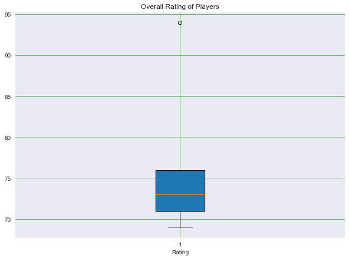

```python
# sns.set_style('darkgrid')
data=above_rating.describe().loc['min':'max',"overall_rating"]
fig=plt.figure(figsize =(10, 7))
plt.boxplot(data,vert=True,patch_artist=True  )
plt.title("Overall Rating of Players")
plt.xlabel('Rating')
plt.grid(color='green', linestyle='-', linewidth = 0.5)
plt.show()
```

##### Penalties

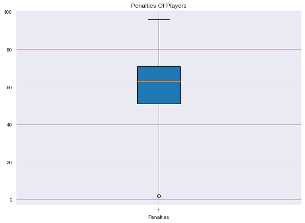

```python
data=above_rating.describe().loc['min':'max',"penalties"]
fig = plt.figure(figsize =(10, 7))
plt.boxplot(data,vert=True,patch_artist=True )
plt.title("Penalties Of Players")
plt.xlabel('Penalties')
plt.grid(color='purple', linestyle='-', linewidth = 0.5)
plt.show()
```

##### Height of Players

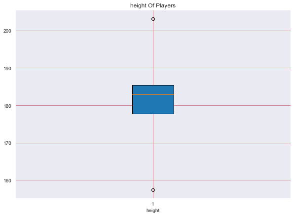

```python
data=pd.DataFrame(above_rating.describe().loc['min':'max',"height"])
fig=plt.figure(figsize =(10, 7))
plt.boxplot(data,vert=True,patch_artist=True )
plt.title("height Of Players")
plt.xlabel('height')
plt.grid(color='brown', linestyle='-', linewidth = 0.5)
plt.show()
```

```python
print(f'Count of players that have an overall rating more than 90 is:', player[(player['overall_rating'] > 90)].player_name.nunique())
```

```
Count of players that have an overall rating more than 90 is: 12
```

> **Let's look at the attributes that contribute to the players' overall rating**

##### Shot Power vs Rating

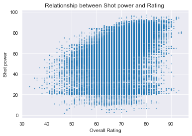

```python
#correlation between shot power and rating
player.plot(x='overall_rating', y='shot_power', kind='scatter', s=0.7, alpha = 0.5)
plt.xlabel('Overall Rating')
plt.ylabel('Shot power');
plt.title('Relationship between Shot power and Rating ');
```

##### Heading

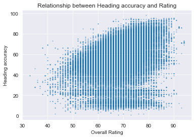

```python
#correlation between heading accuracy and rating
player.plot(x='overall_rating', y='heading_accuracy', kind='scatter', s=0.7, alpha = 0.5)
plt.xlabel('Overall Rating');
plt.ylabel('Heading accuracy');
plt.title('Relationship between Heading accuracy and Rating');
```

##### Ball Control

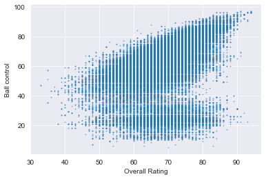

```python
#correlation between  ball control and rating
player.plot(x='overall_rating', y='ball_control', kind='scatter', s=0.7, alpha = 0.5)
plt.xlabel('Overall Rating')
plt.ylabel('Ball control');
plt.title=('Relationship between Ball control and Rating ')
```

##### Strength

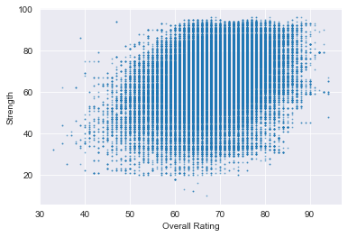

```python
#correlation between strength and rating
player.plot(x='overall_rating', y='strength', kind='scatter', s=0.7, alpha = 0.5)
plt.xlabel('Overall Rating')
plt.ylabel('Strength');
plt.title=('Relationship between Strength and Rating ');
```

##### Marking

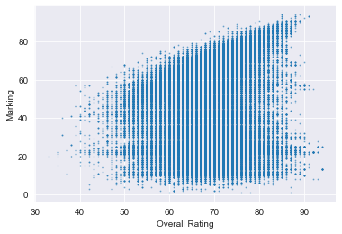

```python
#correlation between marking and rating
player.plot(x='overall_rating', y='marking', kind='scatter', s=0.7, alpha = 0.5)
plt.xlabel('Overall Rating')
plt.ylabel('Marking');
plt.title=('Relationship between Marking and Rating ');
```

##### Long shots

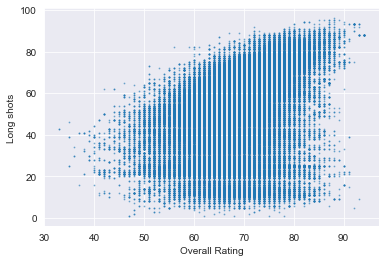

```python
#correlation between long shots and rating
player.plot(x='overall_rating', y='long_shots', kind='scatter', s=0.7, alpha = 0.5)
plt.xlabel('Overall Rating')
plt.ylabel('Long shots')
plt.title=('Relationship between Long shots and Rating ')
```

##### Dribbling

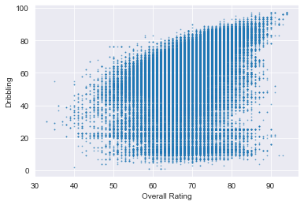

```python
#correlation between dribbling and rating
player.plot(x='overall_rating', y='dribbling', kind='scatter', s=0.7, alpha = 0.5)
plt.xlabel('Overall Rating')
plt.ylabel('Dribbling');
plt.title=('Relationship between Dribbling and Rating ');
```

> **Let's look at the team attributes that lead to the most wins**

```python
top_teams=team[(team["team_long_name"].isin(wins_16.index)) & (team['year'] == 2015)]
```

```python
top_teams
```

|  | id | team_long_name | date | buildUpPlaySpeed | buildUpPlaySpeedClass | buildUpPlayDribblingClass | buildUpPlayPassing | buildUpPlayPassingClass | buildUpPlayPositioningClass | chanceCreationPassing | ... | chanceCreationShootingClass | chanceCreationPositioningClass | defencePressure | defencePressureClass | defenceAggression | defenceAggressionClass | defenceTeamWidth | defenceTeamWidthClass | defenceDefenderLineClass | year |
| --- | --- | --- | --- | --- | --- | --- | --- | --- | --- | --- | --- | --- | --- | --- | --- | --- | --- | --- | --- | --- | --- |
| 370 | 9548 | Paris Saint-Germain | 2015-09-10 | 49 | Balanced | Normal | 34 | Mixed | Organised | 62 | ... | Normal | Organised | 57 | Medium | 53 | Press | 56 | Normal | Cover | 2015 |
| 497 | 15617 | FC Bayern Munich | 2015-09-10 | 45 | Balanced | Little | 28 | Short | Free Form | 37 | ... | Little | Free Form | 72 | High | 53 | Press | 59 | Normal | Cover | 2015 |
| 716 | 20522 | Juventus | 2015-09-10 | 50 | Balanced | Normal | 20 | Short | Organised | 65 | ... | Lots | Organised | 35 | Medium | 65 | Press | 35 | Normal | Cover | 2015 |
| 1052 | 35285 | Sporting CP | 2015-09-10 | 57 | Balanced | Normal | 56 | Mixed | Organised | 42 | ... | Normal | Organised | 60 | Medium | 60 | Press | 54 | Normal | Cover | 2015 |
| 1094 | 35294 | SL Benfica | 2015-09-10 | 69 | Fast | Normal | 53 | Mixed | Organised | 65 | ... | Normal | Organised | 60 | Medium | 57 | Press | 54 | Normal | Cover | 2015 |
| 1179 | 39395 | Celtic | 2015-09-10 | 54 | Balanced | Normal | 53 | Mixed | Organised | 51 | ... | Normal | Organised | 58 | Medium | 55 | Press | 56 | Normal | Cover | 2015 |
| 1244 | 43040 | Real Madrid CF | 2015-09-10 | 50 | Balanced | Normal | 46 | Mixed | Free Form | 61 | ... | Normal | Free Form | 52 | Medium | 60 | Press | 63 | Normal | Cover | 2015 |
| 1256 | 43042 | FC Barcelona | 2015-09-10 | 36 | Balanced | Normal | 51 | Mixed | Free Form | 36 | ... | Normal | Free Form | 61 | Medium | 65 | Press | 65 | Normal | Cover | 2015 |
| 1321 | 43053 | Atlético Madrid | 2015-09-10 | 57 | Balanced | Normal | 50 | Mixed | Organised | 61 | ... | Normal | Organised | 49 | Medium | 42 | Press | 52 | Normal | Cover | 2015 |

9 rows × 24 columns

> Let's see which teams have most wins in 2016

```python
wins_16.index
```

```
Index(['Paris Saint-Germain', 'Juventus', 'SL Benfica', 'FC Barcelona',
       'Real Madrid CF', 'Atlético Madrid', 'FC Bayern Munich', 'Sporting CP',
       'Celtic'],
      dtype='object')
```

```python
digital_attributes=['team_long_name', 'buildUpPlaySpeed', 'buildUpPlayPassing','chanceCreationPassing', 'chanceCreationCrossing', 'chanceCreationShooting','defencePressure', 'defenceAggression', 'defenceTeamWidth']
```

```python
top_teams[digital_attributes].head()
```

|  | team_long_name | buildUpPlaySpeed | buildUpPlayPassing | chanceCreationPassing | chanceCreationCrossing | chanceCreationShooting | defencePressure | defenceAggression | defenceTeamWidth |
| --- | --- | --- | --- | --- | --- | --- | --- | --- | --- |
| 370 | Paris Saint-Germain | 49 | 34 | 62 | 61 | 35 | 57 | 53 | 56 |
| 497 | FC Bayern Munich | 45 | 28 | 37 | 31 | 22 | 72 | 53 | 59 |
| 716 | Juventus | 50 | 20 | 65 | 50 | 80 | 35 | 65 | 35 |
| 1052 | Sporting CP | 57 | 56 | 42 | 50 | 55 | 60 | 60 | 54 |
| 1094 | SL Benfica | 69 | 53 | 65 | 66 | 54 | 60 | 57 | 54 |

> Let's Visualize the results

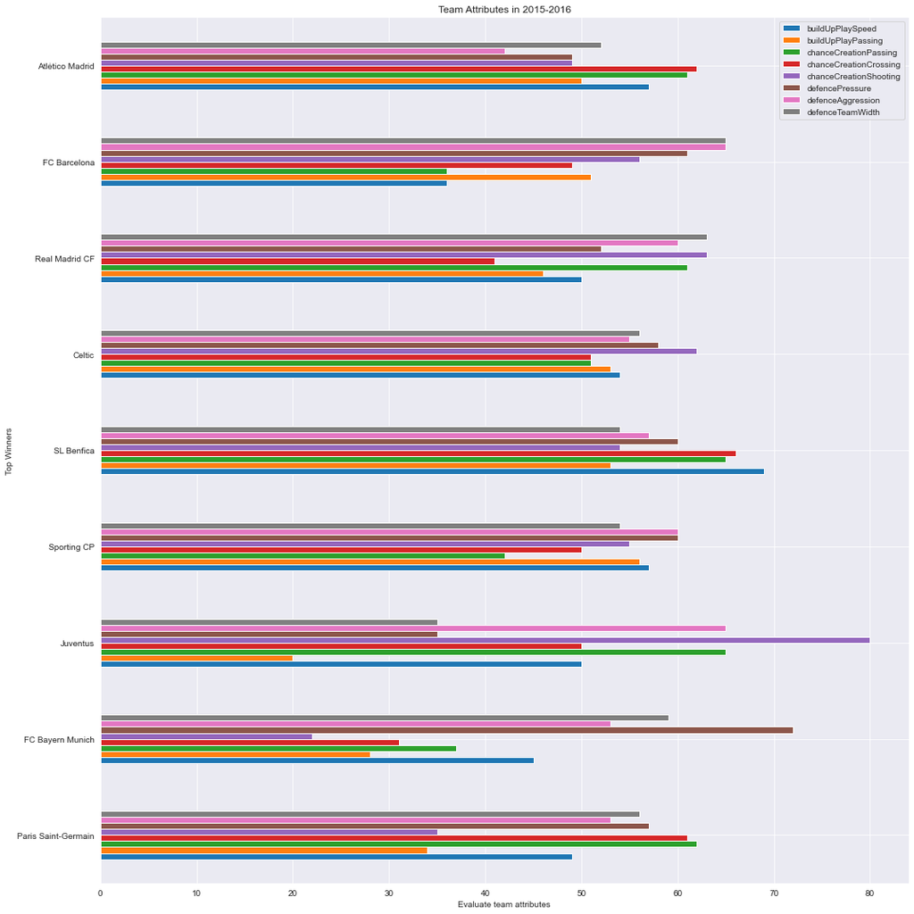

```python
fig, ax = plt.subplots(figsize=(15, 15))
ax = top_teams[digital_attributes].plot.barh(ax=ax);
ax.set_yticklabels(top_teams['team_long_name'])
ax.set_ylabel('Top Winners')
ax.set_title('Team Attributes in 2015-2016')
plt.xlabel("Evaluate team attributes")
plt.tight_layout();
```

```python
descriptive_attributes=['buildUpPlaySpeedClass','buildUpPlayDribblingClass','buildUpPlayPassingClass','buildUpPlayPositioningClass','chanceCreationShootingClass','chanceCreationPositioningClass','defencePressureClass','defenceAggressionClass','defenceTeamWidthClass','defenceDefenderLineClass']
# assign only columns in descriptive_attributes
attributes=top_teams[descriptive_attributes]
```

> **Speed & Dribbling**

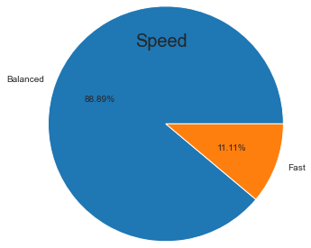

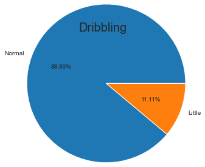

```python
# 1st pie chart here.
plt.figure(0)
plt.pie(attributes['buildUpPlaySpeedClass'].value_counts(),
        labels= attributes['buildUpPlaySpeedClass'].value_counts().index,autopct='%1.2f%%', radius=1.5)
plt.figtext(.5,.8,'Speed',fontsize=20,ha='center')

# Create 2nd chart here.
plt.figure(1)
plt.pie(attributes['buildUpPlayDribblingClass'].value_counts(),
        labels=attributes['buildUpPlayDribblingClass'].value_counts().index,autopct='%1.2f%%', radius=1.5)
plt.figtext(.5,.8,'Dribbling',fontsize=20,ha='center')

plt.show() #show all figures
```

> **Passing & Positioning**

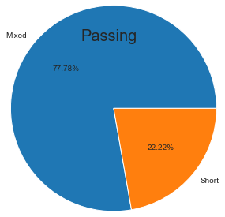

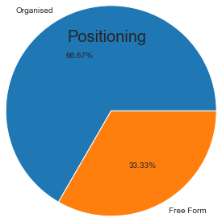

```python
# Create 3rd chart here.
plt.figure(2)
plt.pie(attributes['buildUpPlayPassingClass'].value_counts(),
        labels=attributes['buildUpPlayPassingClass'].value_counts().index,autopct='%1.2f%%', radius=1.5)
plt.figtext(.5,.8,'Passing',fontsize=20,ha='center')

# Create 4th chart here.
plt.figure(3)
plt.pie(attributes['buildUpPlayPositioningClass'].value_counts(),
        labels=attributes['buildUpPlayPositioningClass'].value_counts().index,autopct='%1.2f%%', radius=1.5)
plt.figtext(.5,.8,'Positioning',fontsize=20,ha='center')


plt.show() #show all figures
```

> **Chance Creation Shooting & Chance Creation Positioning**

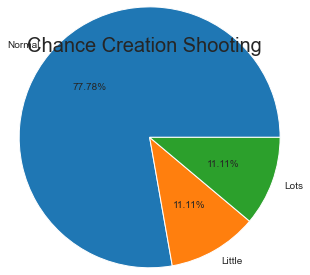

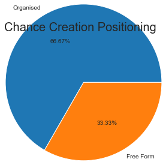

```python
# Create 5th chart here.
plt.figure(4)
plt.pie(attributes['chanceCreationShootingClass'].value_counts(),
        labels=attributes['chanceCreationShootingClass'].value_counts().index,autopct='%1.2f%%', radius=1.5)
plt.figtext(.5,.8,'Chance Creation Shooting',fontsize=20,ha='center')


# Create 6th chart here.
plt.figure(5)
plt.pie(attributes['chanceCreationPositioningClass'].value_counts(),
        labels=attributes['chanceCreationPositioningClass'].value_counts().index,autopct='%1.2f%%', radius=1.5)
plt.figtext(.5,.8,'Chance Creation Positioning',fontsize=20,ha='center')


plt.show() #show all figures
```

> **Defence Pressure & Defence Aggression**

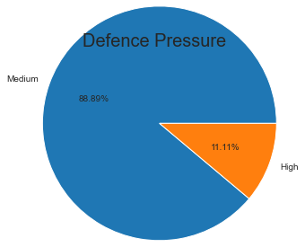

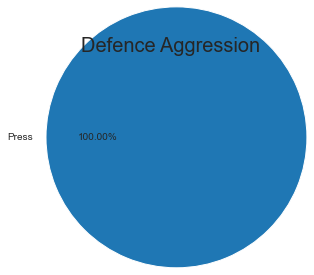

```python
# Create 7th chart here.
plt.figure(6)
plt.pie(attributes['defencePressureClass'].value_counts(),
        labels=attributes['defencePressureClass'].value_counts().index,autopct='%1.2f%%', radius=1.5)
plt.figtext(.5,.8,'Defence Pressure',fontsize=20,ha='center')


# Create 8th chart here.
plt.figure(7)
plt.pie(attributes['defenceAggressionClass'].value_counts(),
        labels=attributes['defenceAggressionClass'].value_counts().index,autopct='%1.2f%%', radius=1.5)
plt.figtext(.5,.8,'Defence Aggression',fontsize=20,ha='center')


plt.show() #show all figures
```

> **Defence Team Width & Defence Defender Line**

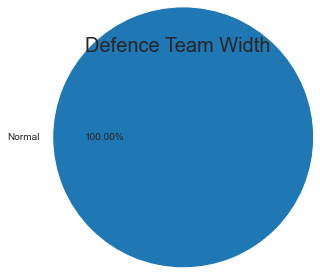

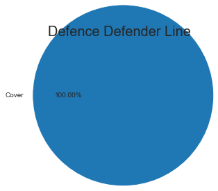

```python
# Create 9th chart here.
plt.figure(8)
plt.pie(attributes['defenceTeamWidthClass'].value_counts(),
        labels=attributes['defenceTeamWidthClass'].value_counts().index,autopct='%1.2f%%', radius=1.5)
plt.figtext(.5,.8,'Defence Team Width',fontsize=20,ha='center')


# Create 10th chart here.
plt.figure(9)
plt.pie(attributes['defenceDefenderLineClass'].value_counts(),
        labels=attributes['defenceDefenderLineClass'].value_counts().index,autopct='%1.2f%%', radius=1.5)
plt.figtext(.5,.8,'Defence Defender Line',fontsize=20,ha='center')


plt.show() #show all figures
```

> **Let's look at which players had the most penalties**

##### Select top player name and their penalties in descending order

```python
most_penalties=player.groupby(['player_name'])['penalties'].max().sort_values(ascending=False)
most_penalties[:10]
```

```
player_name
Rickie Lambert     96.0
Andrea Pirlo       95.0
Xavi Hernandez     95.0
Paul Scholes       95.0
Mario Balotelli    95.0
Adrian Mutu        94.0
Cesc Fabregas      94.0
Iker Casillas      94.0
David Trezeguet    94.0
Fernando Torres    93.0
Name: penalties, dtype: float64
```

> Let's visualize this

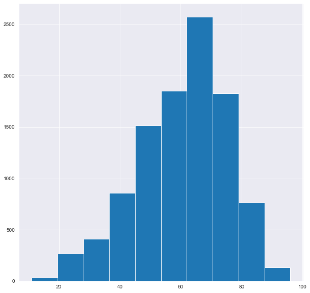

```python
# most_penalties.plot(kind='hist');
# plt.xlabel('Penalties');
# plt.ylabel('Number');
# plt.title=('Penalties of Player');

most_penalties.hist(figsize=(10,10));
```

```python
from subprocess import call
call(['python', '-m', 'nbconvert', 'Soccer Database Analysis.ipynb'])
```

```
1
```